# Iterative procedure with DYN3D

First, cross sections are read from a serpent `_res.m` file. This notebook shows how to execute DYN3D iteratively using the `Iterate` method.

It is important to note that the solution presented here was validated against a consistent semi-analytic solution (not presented here).

## Case Description

[figure not shown]

The `.\inputs` directory includes:

- `nuScale_00_xsgen2g_res.m` a serpent results file with all the cross sections.
- `univs` a file that describes how to read `nuScale_00_xsgen2g_res.m`
- `template_dyn3d_2g_fuel` is a template file that specifies how cross sections should be printed out for the fuel and `template_dyn3d_2g_refl` for the reflector.
- `controlDict` the main files that is required by the `xsInterface`.

The `.\dyn3d` includes a pre-generated DYN3D case. The `.\dyn3d\xs` directory will include all the files with printed cross sections required by DYN3D.

### Required imports

```python
from xsInterface.functions.main import Main
```

```python
# a class required to execute DYN3D
from xsInterface.functions.dyn3d import DYN3D
```

```python
inputFile = ".\\inputs\\controlDict"
```

### Read the cross sections

```python
# Reset the main object
xs = Main(inputFile)
```

```
... Reading control dict ...
<.\inputs\controlDict>
```

#### Read xs data without populating the templates

```python
# readTemplate allows to read and populate data using the templates
xs.Read(readUniverses=True)
```

```
... Reading universe <u> ...
... Reading coe/_res.m file for hisotry <nom> ...
```

### Populate cross sections

In the `".\\inputs\\controlDict"` the user defined the core map used to populate the cross sections according to their channels and layers positions.

**Define states** These states must exist and be used to obtain the cross sections for different channels and layers.

```python
nchs = 4
nlayers = 1
states = {
'history':[['nom']*nlayers]*nchs,
'time': [[0.0]*nlayers]*nchs,
'dens': [[700.]*nlayers]*nchs,}
```

**Populate core data** built-in capability to populate the data according to the defined map including defining new variables not listed in the original `univs` file. This is a **mandaory** step if the intent is to execute DYN3D.

```python
volmanip = {'infflx': 'divide'}
xs.PopulateCoreData(
                    states=states,
                    attributes=None,  # specify only if specific attrs needed
                    volManip=volmanip,
                    adf=None, bottomadf=None, topadf=None, sph=None,)
```

### Iteratively execute DYN3D

```python
casedir = ".\\dyn3d"   # dyn3d dir
casefile = "2x2PWR2g"  # name of dyn3d file
exefile = "RUN_DYN3D" # dyn3d executuin file

# Reset the object
reslt = DYN3D(xs, casedir, casefile, exefile)
```

**Set the refernce flux**

```python
refFlx = xs.core.corevalues['infflx']
```

**Execute**

The files will be written to the specified directories and then automatically executed.

```python
reslt.Iterate(
    corrattrs=['adf'], refFlx=refFlx, newtonIters=7,
    dampingF=0.8, lbound=0.9, ubound=1.1, pert=1E-03)
```

```
... Iterative JFNK ...
Newton #0/7
Arnoldi # 1 2 3 4 5
Newton #1/7
Arnoldi # 1 2 3 4 5
Newton #2/7
Arnoldi # 1 2 3 4 5
Newton #3/7
Arnoldi # 1 2 3 4
Newton #4/7
Arnoldi # 1 2 3 4 5
Newton #5/7
Arnoldi # 1 2 3 4
Newton #6/7
Arnoldi # 1 2 3 4
```

### Compare results against Serpent

Plot the results for flux and its corresponding difference. Finally, plot the convergence as a function of newton iteration number.

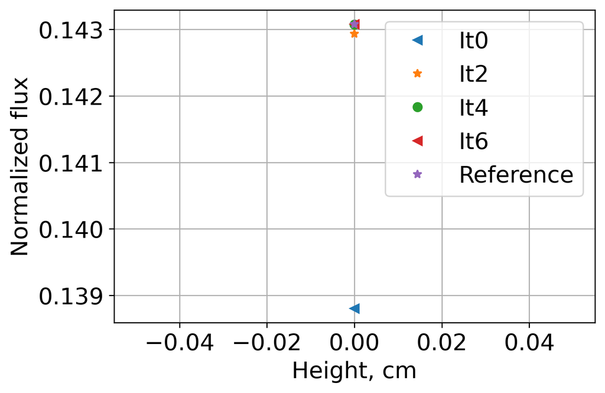

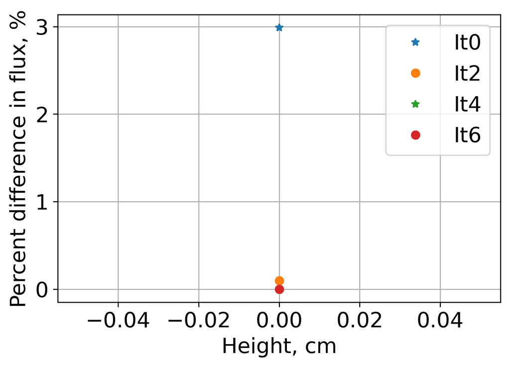

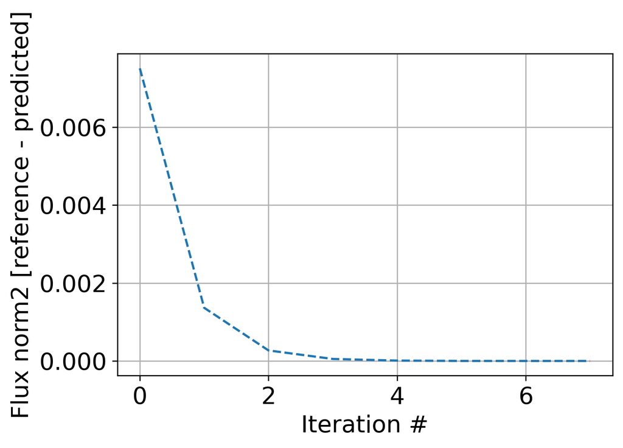

```python
import numpy as np
reslt.PlotFluxes([0], iters=np.array([0, 2, 4, 6]),  markers=['<', '*', 'o'], chId="RR4")
```

**Plot the reference fluxes in the Fast group and Thermal group respectively**

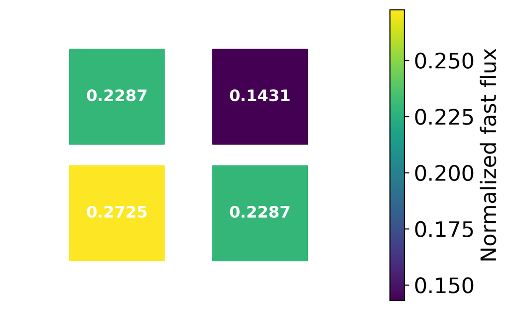

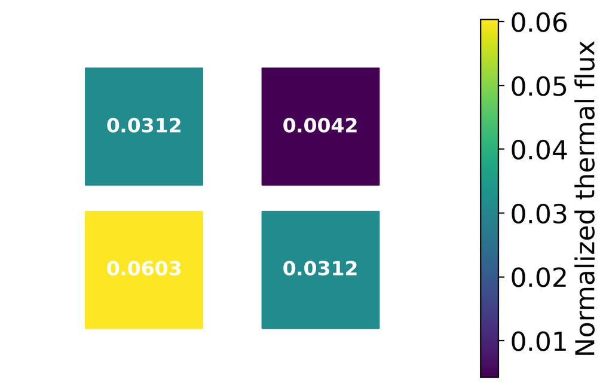

```python
xs.SlicePlot(reslt.refFlx, layer=0, markersize=5000, spacesize=2.0,
              textsize=12, textcolor='w', textweight="bold",
              precision=".4f", edge=1.5, norm=1.0, label="Normalized fast flux",
              egroup=0)

xs.SlicePlot(reslt.refFlx, layer=0, markersize=5000, spacesize=2.0,
              textsize=12, textcolor='w', textweight="bold",
              precision=".4f", edge=1.5, norm=1.0, label="Normalized thermal flux",
              egroup=1)
```

**Plot the flux differences in the Fast group and Thermal group respectively** Without iterating on ADFs.

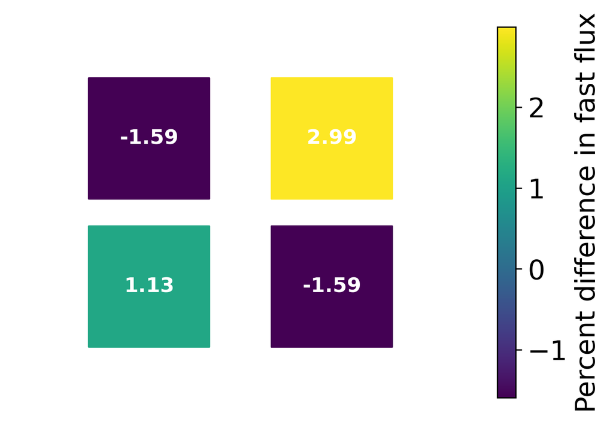

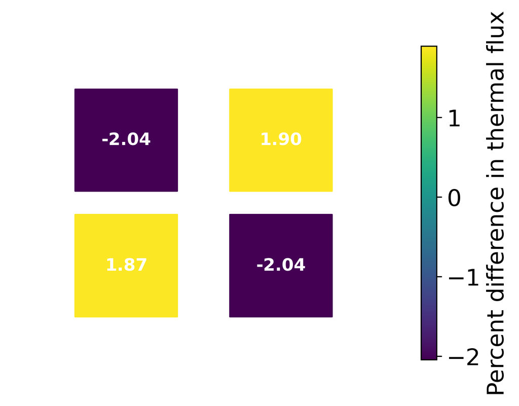

```python
xs.SlicePlot(reslt.iterDifferences[0], layer=0, markersize=5000, spacesize=2.0,
              textsize=12, textcolor='w', textweight="bold",
              precision=".2f", edge=1.5, norm=1.0, label="Percent difference in fast flux",
              egroup=0)

xs.SlicePlot(reslt.iterDifferences[0], layer=0, markersize=5000, spacesize=2.0,
              textsize=12, textcolor='w', textweight="bold",
              precision=".2f", edge=1.5, norm=1.0, label="Percent difference in thermal flux",
              egroup=1)
```

**Plot the flux differences in the Fast group and Thermal group respectively** After iterating on ADFs.

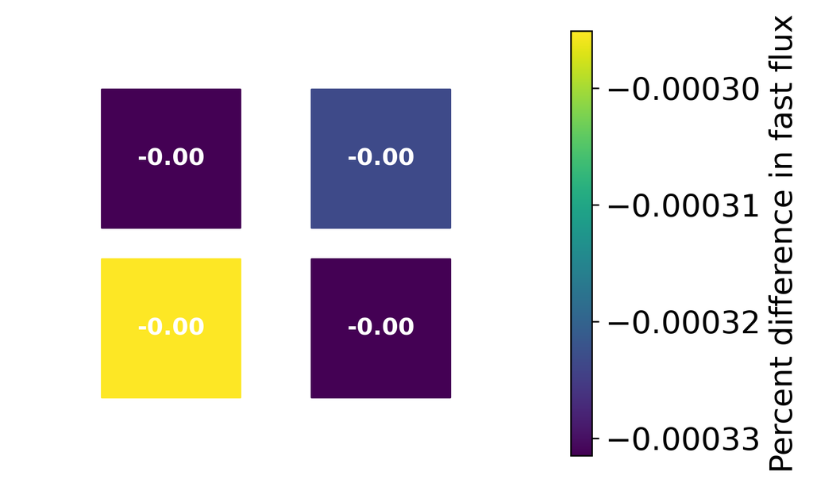

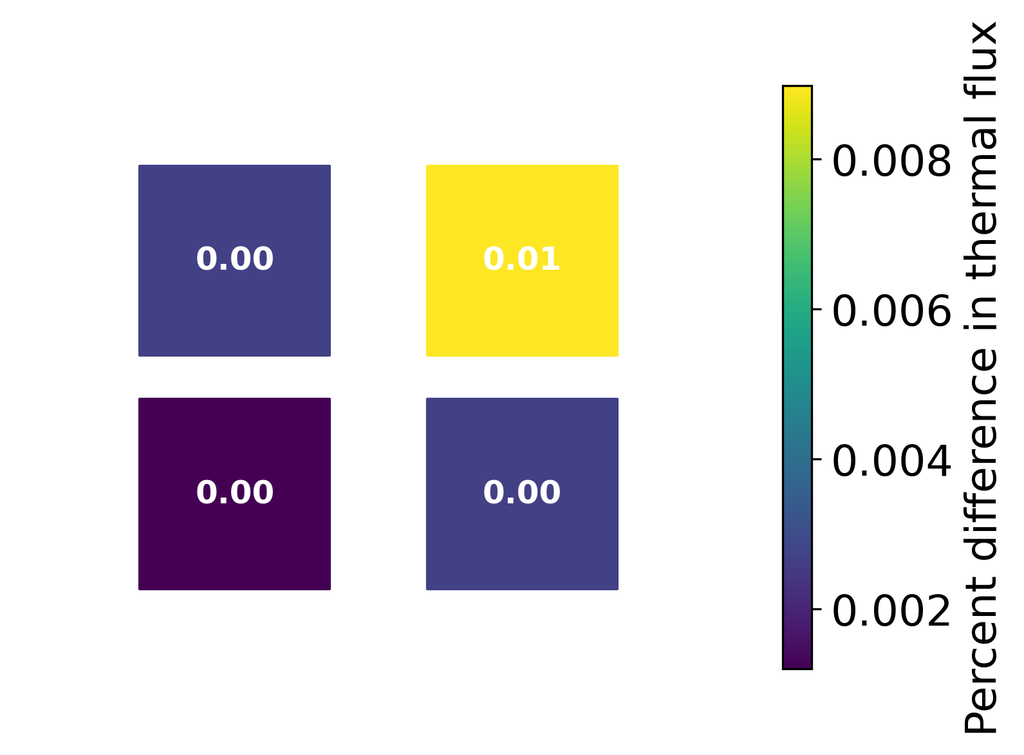

```python
xs.SlicePlot(reslt.iterDifferences[-1], layer=0, markersize=5000, spacesize=2.0,
              textsize=12, textcolor='w', textweight="bold",
              precision=".2f", edge=1.5, norm=1.0, label="Percent difference in fast flux",
              egroup=0)

xs.SlicePlot(reslt.iterDifferences[-1], layer=0, markersize=5000, spacesize=2.0,
              textsize=12, textcolor='w', textweight="bold",
              precision=".2f", edge=1.5, norm=1.0, label="Percent difference in thermal flux",
              egroup=1)
```

**Plot the resulting ADFs in the Fast group and Thermal group respectively**

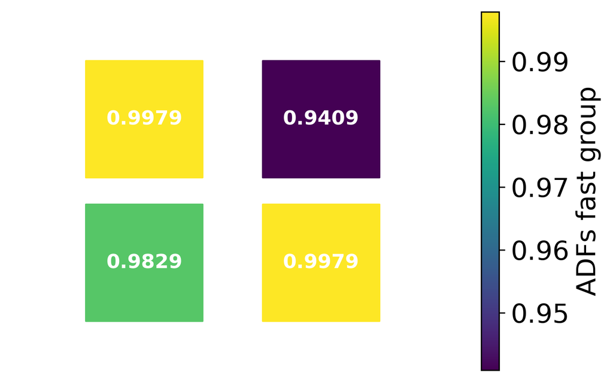

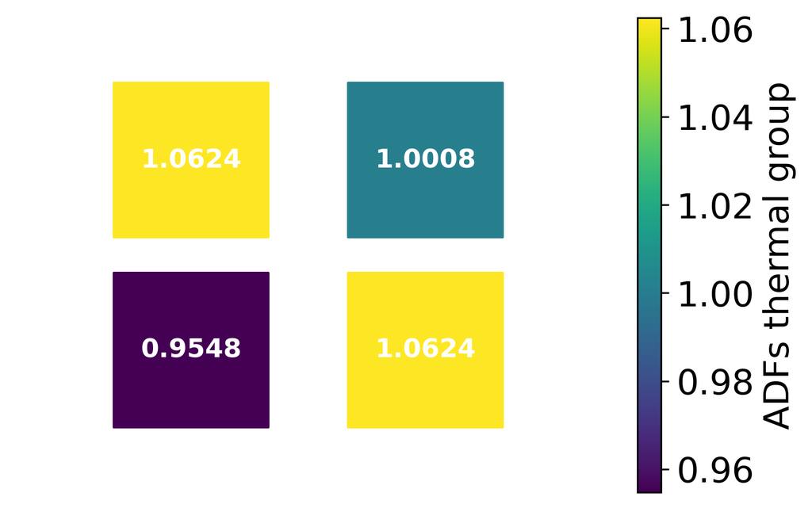

```python
xs.SlicePlot(reslt.iterInputs['adf'][-1], layer=0, markersize=5000, spacesize=2.0,
              textsize=12, textcolor='w', textweight="bold",
              precision=".4f", edge=1.5, norm=1.0, label="ADFs fast group",
              egroup=0)

xs.SlicePlot(reslt.iterInputs['adf'][-1], layer=0, markersize=5000, spacesize=2.0,
              textsize=12, textcolor='w', textweight="bold",
              precision=".4f", edge=1.5, norm=1.0, label="ADFs thermal group",
              egroup=1)
```